# **Hipotesis 1. Temperatura y delitos en Medellín**

**Santiago Arboleda Quiroz**

**Olga Lucía Montoya Pérez**

Sistema másivo de bases de datos - 2020

# **Tabla de contenido**

1. Limpieza de datos

2. Bodega de datos

3. Preguntas a resolver

4. Diagramas de base de datos

5. MapReduce

6. Visualizar hipótesis

7. Predicción

Librerías

```python
import pandas as pd
import numpy as np
import seaborn as sn
import matplotlib.pyplot as plt
import datetime

from math import sin, cos, sqrt, atan2, radians
from sklearn.metrics import mean_squared_error as MSE
from google.colab import drive
from IPython.display import Image
from fbprophet import Prophet
from datetime import datetime

drive.mount('/gdrive')
```

```
Go to this URL in a browser: https://accounts.google.com/o/oauth2/auth?client_id=947318989803-6bn6qk8qdgf4n4g3pfee6491hc0brc4i.apps.googleusercontent.com&redirect_uri=urn%3aietf%3awg%3aoauth%3a2.0%3aoob&response_type=code&scope=email%20https%3a%2f%2fwww.googleapis.com%2fauth%2fdocs.test%20https%3a%2…

Enter your authorization code:
··········
Mounted at /gdrive
```

# **1. Lectura de archivos fuentes, análisis de información y limpieza de datos**

Cabe mencionar que en las fuentes a tratar no todos los registros siguen la estructura, por lo cual estos registros no serán considerados.

Para cada una de las fuentes de datos, se realizará el análisis de valores vacios, valores nulos y valores únicos por columna, esta información será insumo para realizar la limpieza de datos.

```python
temperatura = pd.read_csv('/gdrive/My Drive/SMBD/Temperatura_Med_2018_2019.csv')
temperatura.head(2)
```

|  | CodigoEstacion | CodigoSensor | FechaObservacion | ValorObservado | NombreEstacion | Departamento | Municipio | ZonaHidrografica | Latitud | Longitud | DescripcionSensor | UnidadMedida |
| --- | --- | --- | --- | --- | --- | --- | --- | --- | --- | --- | --- | --- |
| 0 | 27015290 | 69 | 11/21/2018 06:00:00 AM | 17.6 | PAJARITO - AUT | ANTIOQUIA | MEDELLÍN | NECHÍ | 6.286333 | -75.612792 | Temp Max Aire 2 m | °C |
| 1 | 27015330 | 69 | 09/21/2018 04:56:00 AM | 20.3 | APTO OLAYA HERRERA - TX GPRS | ANTIOQUIA | MEDELLÍN | NECHÍ | 6.221000 | -75.589000 | Temp Max Aire 2 m | °C |

```python
#**Cantidad de registros Temperatura ***
temperatura.shape
```

```
(45173, 12)
```

```python
#**Nulos Temperatura ***
temp_null = (temperatura.isna() == True).astype(int).sum(axis=0).sort_values(ascending=False)
percent_temp_null = (temperatura.isna().sum() *100/temperatura.isna().count())
null_temp_data = pd.concat([temp_null, percent_temp_null], axis=1, keys=['Total_Nulos_Temperatura', 'Porcentaje_Nulos_Temp'])
null_temp_data[null_temp_data['Total_Nulos_Temperatura'] > 0]
```

|  | Total_Nulos_Temperatura | Porcentaje_Nulos_Temp |
| --- | --- | --- |

```python
#**Ceros Temperatura ***
temp_ceros = (temperatura == 0).astype(int).sum(axis=0).sort_values(ascending=False)
percent_temp_ceros = ((temperatura == 0).sum(axis=0) *100/(temperatura == 0).count())
cero_temp_data = pd.concat([temp_ceros, percent_temp_ceros], axis=1, keys=['Total_ceros_Temp', 'Porcentaje_ceros_Temp'])
cero_temp_data[cero_temp_data['Total_ceros_Temp'] > 0]
```

|  | Total_ceros_Temp | Porcentaje_ceros_Temp |
| --- | --- | --- |

```python
#**Valores únicos por Temperatura ***
temperatura.nunique()
```

```
CodigoEstacion           2
CodigoSensor             1
FechaObservacion     40711
ValorObservado         207
NombreEstacion           2
Departamento             1
Municipio                1
ZonaHidrografica         1
Latitud                  2
Longitud                 2
DescripcionSensor        1
UnidadMedida             1
dtype: int64
```

```python
temperatura.drop_duplicates(subset=['CodigoEstacion','NombreEstacion','Latitud','Longitud'])
```

|  | CodigoEstacion | CodigoSensor | FechaObservacion | ValorObservado | NombreEstacion | Departamento | Municipio | ZonaHidrografica | Latitud | Longitud | DescripcionSensor | UnidadMedida |
| --- | --- | --- | --- | --- | --- | --- | --- | --- | --- | --- | --- | --- |
| 0 | 27015290 | 69 | 11/21/2018 06:00:00 AM | 17.6 | PAJARITO - AUT | ANTIOQUIA | MEDELLÍN | NECHÍ | 6.286333 | -75.612792 | Temp Max Aire 2 m | °C |
| 1 | 27015330 | 69 | 09/21/2018 04:56:00 AM | 20.3 | APTO OLAYA HERRERA - TX GPRS | ANTIOQUIA | MEDELLÍN | NECHÍ | 6.221000 | -75.589000 | Temp Max Aire 2 m | °C |

El dataset de temperatura de Medellín, no contiene valores nulos, ni en cero.

Las dimensiones de CodigoSensor, Departamente, Municipio, zonaHidrografica, DescripcioSensor, UnidadMedia no aportan variabilidad en la información, por lo cual estas dimensiones pueden ser eliminadas. Por su parte, la información de CodigoEstacion, NombreEstacion hacen referencia al sesor que capturó la información, para el análisis es suficiente dejar uno de los campos, se opta por dejar el CodigoEstación y los demás eliminarlos.

Con esto, el dataset original de 12 dimensiones pasa a ser de 5 dimensiones

```python
temperatura_dep = temperatura[['CodigoEstacion','FechaObservacion','ValorObservado', 'Latitud', 'Longitud']]
```

```python
homicidios = pd.read_csv('/gdrive/My Drive/SMBD/Homicidios__2018_2020.csv', error_bad_lines=False)
homicidios.head(2)
```

[output not shown]

|  | fecha_hecho | cantidad | latitud | longitud | sexo | edad | estado_civil | grupo_actor | actividad_delictiva | parentesco | ocupacion | discapacidad | grupo_especial | medio_transporte | nivel_academico | testigo | conducta | modalidad | caracterizacion | conducta_especial | arma_medio | articulo_penal | categoria_penal | nombre_barrio | codigo_barrio | codigo_comuna | lugar | sede_receptora | bien | … |
| --- | --- | --- | --- | --- | --- | --- | --- | --- | --- | --- | --- | --- | --- | --- | --- | --- | --- | --- | --- | --- | --- | --- | --- | --- | --- | --- | --- | --- | --- | --- |
| 0 | 2018-01-20 20:35:00 | 1.0 | 6.276724 | -75.607605 | Hombre | 32 | Soltero | NaN | NaN | NaN | NaN | NaN | Consumidor de estupefacientes | Caminata | Primaria | Sin dato | Homicidio | Arma de fuego | Grupos Delincuenciales Organizados | Sin dato | Sin dato | Sin dato | Sin dato | Fuente Clara | 0719 | 7 | Quebrada o rio | NaN | Sin dato | … |
| 1 | 2018-06-06 00:00:00 | 1.0 | 6.247837 | -75.620079 | Hombre | 15 | Soltero | NaN | NaN | NaN | Estudiante | NaN | NaN | Caminata | Bachillerato | Sin dato | Homicidio | Arma de fuego | Grupos Delincuenciales Organizados | Sin dato | Sin dato | Sin dato | Sin dato | Veinte de Julio | 1310 | 13 | Vía pública | NaN | Sin dato | … |

```python
#**Cantidad de registros Homicidios ***
homicidios.shape
```

```
(1131, 35)
```

```python
#**Nulos Homicidios ***
hom_null = (homicidios.isna() == True).astype(int).sum(axis=0).sort_values(ascending=False)
percent_hom_null = (homicidios.isna().sum() *100/homicidios.isna().count())
null_hom_data = pd.concat([hom_null, percent_hom_null], axis=1, keys=['Total_Nulos_Homic', 'Porcentaje_Nulos_Homic'])
null_hom_data[null_hom_data['Total_Nulos_Homic'] > 0]
```

|  | Total_Nulos_Homic | Porcentaje_Nulos_Homic |
| --- | --- | --- |
| discapacidad | 1091 | 96.463307 |
| parentesco | 1072 | 94.783378 |
| grupo_actor | 1070 | 94.606543 |
| actividad_delictiva | 1026 | 90.716180 |
| grupo_especial | 923 | 81.609195 |
| sede_receptora | 905 | 80.017683 |
| nivel_academico | 530 | 46.861185 |
| estado_civil | 481 | 42.528736 |
| medio_transporte | 363 | 32.095491 |
| ocupacion | 154 | 13.616269 |
| lugar | 20 | 1.768347 |

```python
#**Ceros Homicidios ***
hom_ceros = (homicidios == 0).astype(int).sum(axis=0).sort_values(ascending=False)
percent_hom_ceros = ((homicidios == 0).sum(axis=0) *100/(homicidios == 0).count())
cero_hom_data = pd.concat([hom_ceros, percent_hom_ceros], axis=1, keys=['Total_ceros_Homi', 'Porcentaje_ceros_Homi'])
cero_hom_data[cero_hom_data['Total_ceros_Homi'] > 0]
```

|  | Total_ceros_Homi | Porcentaje_ceros_Homi |
| --- | --- | --- |

```python
#**Valores únicos por Homicidios ***
homicidios.nunique()
```

```
fecha_hecho            1045
cantidad                  1
latitud                1070
longitud               1042
sexo                      2
edad                     68
estado_civil              5
grupo_actor               4
actividad_delictiva      13
parentesco               11
ocupacion                66
discapacidad              4
grupo_especial           15
medio_transporte          9
nivel_academico           7
testigo                   1
conducta                  1
modalidad                 8
caracterizacion           8
conducta_especial         1
arma_medio                1
articulo_penal            1
categoria_penal           1
nombre_barrio           236
codigo_barrio           243
codigo_comuna            21
lugar                    33
sede_receptora           25
bien                      1
categoria_bien            1
grupo_bien                1
modelo                    1
color                     1
permiso                   1
unidad_medida             1
dtype: int64
```

El dataset de homicidios, no contiene valores en cero.

En cuanto al análisis de valores nulos, para las dimensiones de discapacidad, parentesco, grupo_actor, actividad_delictiva, grupo_especial, sede_receptora, nivel_academico, estado_civil y medio_transporte más del 30% de los datos son nulos, por lo cual no serán usadas dentro del análisis. Para la demás variables con valores nulos como ocupacion y lugar, las cuales no son tan representativos los valores nulos, se dejaran como estan.

Por su parte, las variables de cantidad, testigo, conducta, conducta_especial, arma_medio, articulo_penal, categoria_penal, bien, categoria_bien, grupo_bien, modelo, color, permiso, unidad_medida, quienes dentro de los posibles valores solo tienen uno, no serán tenidas en cuenta, puesto que no aportan variabilidad al análisis.

Es importante mencionar que como el dataset de homicidios será integrado con el de hurtos, hay variables que aplican en hurtos que no aplican en homicidios, por lo tanto se dejarán algunas de estas para efectos de integración, así en el apartado anterior se haya indicado que se eliminarían.

```python
homicidios_dep = homicidios[['fecha_hecho', 'sexo', 'edad',  'estado_civil', 'ocupacion', 'modalidad', 'caracterizacion',
                              'nombre_barrio', 'codigo_comuna',  'latitud', 'longitud',
                              'conducta_especial', 'arma_medio', 'lugar', 'sede_receptora','bien','categoria_bien',
                              'grupo_bien','modelo', 'color','permiso','unidad_medida']]
```

```python
#Creación de identificador para el dataset de homicidios
homicidios_dep['Tipo'] = 'Homicidio'
```

```python
homicidios_dep.shape
```

```
(1131, 23)
```

```python
hurto_personas = pd.read_csv('/gdrive/My Drive/SMBD/Hurto_Personas__2018_2020.csv',  warn_bad_lines=False, error_bad_lines=False)
hurto_residencias = pd.read_csv('/gdrive/My Drive/SMBD/Hurto_Residencias__2018_2020.csv', warn_bad_lines=False, error_bad_lines=False)

hurto_personas.columns = hurto_personas.columns.str.replace('seguridad.','')
hurto_residencias.columns = hurto_residencias.columns.str.replace('seguridad.','')

frames = [hurto_personas, hurto_residencias]
hurtos = pd.concat(frames)
hurtos.head(2)
```

|  | fecha_hecho | cantidad | latitud | longitud | sexo | edad | estado_civil | grupo_actor | actividad_delictiva | parentesco | ocupacion | discapacidad | grupo_especial | medio_transporte | nivel_academico | testigo | conducta | modalidad | caracterizacion | conducta_especial | arma_medio | articulo_penal | categoria_penal | nombre_barrio | codigo_barrio | codigo_comuna | lugar | sede_receptora | bien | … |
| --- | --- | --- | --- | --- | --- | --- | --- | --- | --- | --- | --- | --- | --- | --- | --- | --- | --- | --- | --- | --- | --- | --- | --- | --- | --- | --- | --- | --- | --- | --- |
| 0 | 2019-01-01 19:30:00 | 1.0 | 6.301506 | -75.56368 | Mujer | 24 | Soltero(a) | Sin dato | Sin dato | Sin dato | Sin dato | Sin dato | Sin dato | Motocicleta con parrillero | Sin dato | Sin dato | Hurto a persona | Raponazo | Sin dato | No | No | Sin dato | Sin dato | Plaza de Ferias | #Inst_1 | 5 | Vía pública | Castilla | Licencia | … |
| 1 | 2019-01-01 10:30:00 | 1.0 | 6.278288 | -75.57016 | Hombre | 26 | Soltero(a) | Sin dato | Sin dato | Sin dato | Sin dato | Sin dato | Sin dato | Caminata | Sin dato | Sin dato | Hurto a persona | Descuido | Sin dato | Sin dato | No | Sin dato | Sin dato | Terminal de Transporte | #Inst_4 | 5 | Estación del Metro | Castilla | Sin dato tecnología | … |

```python
#**Cantidad de registros Hurtos ***
hurtos.shape
```

```
(60876, 35)
```

```python
#**Nulos Hurtos ***
hur_null = (hurtos.isna() == True).astype(int).sum(axis=0).sort_values(ascending=False)
percent_hur_null = (hurtos.isna().sum() *100/hurtos.isna().count())
null_hur_data = pd.concat([hur_null, percent_hur_null], axis=1, keys=['Total_Nulos_Hurtos', 'Porcentaje_Nulos_Hurto'])
null_hur_data[null_hur_data['Total_Nulos_Hurtos'] > 0]
```

|  | Total_Nulos_Hurtos | Porcentaje_Nulos_Hurto |
| --- | --- | --- |

```python
#**Ceros Hurtos ***
hur_ceros = (hurtos == 0).astype(int).sum(axis=0).sort_values(ascending=False)
percent_hur_ceros = ((hurtos == 0).sum(axis=0) *100/(hurtos == 0).count())
cero_hur_data = pd.concat([hur_ceros, percent_hur_ceros], axis=1, keys=['Total_ceros_Hurtos', 'Porcentaje_ceros_Hurtos'])
cero_hur_data[cero_hur_data['Total_ceros_Hurtos'] > 0]
```

|  | Total_ceros_Hurtos | Porcentaje_ceros_Hurtos |
| --- | --- | --- |

```python
#**Valores únicos por Hurtos ***
hurtos.nunique()
```

```
fecha_hecho            26218
cantidad                   1
latitud                37457
longitud               36772
sexo                       2
edad                      91
estado_civil               6
grupo_actor                1
actividad_delictiva        1
parentesco                 1
ocupacion                  1
discapacidad               1
grupo_especial             1
medio_transporte          10
nivel_academico            1
testigo                    1
conducta                   2
modalidad                 19
caracterizacion            1
conducta_especial         17
arma_medio                 9
articulo_penal             1
categoria_penal            1
nombre_barrio            319
codigo_barrio            319
codigo_comuna             42
lugar                     85
sede_receptora            18
bien                     323
categoria_bien           128
grupo_bien                40
modelo                    13
color                     18
permiso                   16
unidad_medida             12
dtype: int64
```

El dataset de hurtos esta conformado por la información de hurtos a personas y a residencias, dentro de la integración de estos dataset no se encuentran valores nulos ni valores en cero. En cuanto a las variables que tienen poca variabilidad en su contenido se tienen la cantidad, grupo_actor, actividad_delictiva, parentesco, ocupacion, discapacidad, grupo_especial, nivel_academico, testico, conducta, caracterizacion, articulo_penal, categoria_penal, las cuales pueden ser omitidas del dataset final.

```python
hurtos_dep = hurtos[['fecha_hecho','sexo', 'edad','estado_civil', 'ocupacion',
                    'modalidad', 'caracterizacion', 'nombre_barrio', 'codigo_comuna',
                    'latitud', 'longitud', 'conducta_especial', 'arma_medio', 'lugar',
                     'sede_receptora','bien','categoria_bien','grupo_bien','modelo',
                    'color','permiso','unidad_medida']]
hurtos_dep.shape
```

```
(60876, 22)
```

```python
hurtos_dep['Tipo'] = 'Hurto'
```

# **2. Bodega de datos**

**Entendimiento y preparacion de datos**

Una vez depurado los datasets de temperatura, homicidios y hurtos, se procede realizar ajustes sobre los datos para prepararlos para el posterior análisis

*Se procede a dar formato a las fechas de los datasets*

```python
temperatura_dep['FechaObservacion'] = pd.to_datetime(temperatura_dep['FechaObservacion'])
temperatura_dep['FechaObservacion'] = temperatura_dep['FechaObservacion'].dt.date
temperatura_dep['FechaObservacion']
```

```
0        2018-11-21
1        2018-09-21
2        2018-03-06
3        2018-06-10
4        2018-09-10
            ...
45168    2019-12-31
45169    2019-12-31
45170    2019-12-31
45171    2019-12-31
45172    2019-12-31
Name: FechaObservacion, Length: 45173, dtype: object
```

```python
homicidios_dep['fecha_hecho'] = pd.to_datetime(homicidios_dep['fecha_hecho'])
homicidios_dep['fecha_hecho'] = homicidios_dep['fecha_hecho'].dt.date
homicidios_dep['fecha_hecho']
```

```
0       2018-01-20
1       2018-06-06
2       2018-04-15
3       2018-03-25
4       2018-03-21
           ...
1126    2018-10-15
1127    2018-07-26
1128    2018-08-03
1129    2018-08-20
1130    2018-07-12
Name: fecha_hecho, Length: 1131, dtype: object
```

```python
hurtos_dep['fecha_hecho'] = pd.to_datetime(hurtos_dep['fecha_hecho'])
hurtos_dep['fecha_hecho'] = hurtos_dep['fecha_hecho'].dt.date
hurtos_dep['fecha_hecho']
```

```
0       2019-01-01
1       2019-01-01
2       2019-01-01
3       2019-01-01
4       2019-01-01
           ...
1063    2018-06-13
1064    2018-09-22
1065    2018-09-24
1066    2018-10-06
1067    2018-12-27
Name: fecha_hecho, Length: 60876, dtype: object
```

*Unificación de dataset de homicidios y hurtos, llamado delincuencia*

```python
delincuencia_frames = [hurtos_dep, homicidios_dep]
delincuencia = pd.concat(delincuencia_frames)
delincuencia.head(2)
```

|  | fecha_hecho | sexo | edad | estado_civil | ocupacion | modalidad | caracterizacion | nombre_barrio | codigo_comuna | latitud | longitud | conducta_especial | arma_medio | lugar | sede_receptora | bien | categoria_bien | grupo_bien | modelo | color | permiso | unidad_medida | Tipo |
| --- | --- | --- | --- | --- | --- | --- | --- | --- | --- | --- | --- | --- | --- | --- | --- | --- | --- | --- | --- | --- | --- | --- | --- |
| 0 | 2019-01-01 | Mujer | 24 | Soltero(a) | Sin dato | Raponazo | Sin dato | Plaza de Ferias | 5 | 6.301506 | -75.56368 | No | No | Vía pública | Castilla | Licencia | Documentos | Mercancía | -1 | Sin dato | Sin dato | Sin dato | Hurto |
| 1 | 2019-01-01 | Hombre | 26 | Soltero(a) | Sin dato | Descuido | Sin dato | Terminal de Transporte | 5 | 6.278288 | -75.57016 | Sin dato | No | Estación del Metro | Castilla | Sin dato tecnología | Tecnología | Mercancía | -1 | Sin dato | Sin dato | Sin dato | Hurto |

```python
delincuencia.shape
```

```
(62007, 23)
```

*Agregacón de temperatura promedio por sensor y día*

```python
temperatura_prom = temperatura_dep.groupby(['CodigoEstacion','FechaObservacion'], as_index=False)['Latitud','Longitud', 'ValorObservado'].mean()
temperatura_prom.head(2)
```

|  | CodigoEstacion | FechaObservacion | Latitud | Longitud | ValorObservado |
| --- | --- | --- | --- | --- | --- |
| 0 | 27015290 | 2018-01-01 | 6.286333 | -75.612792 | 17.875000 |
| 1 | 27015290 | 2018-01-02 | 6.286333 | -75.612792 | 18.129167 |

*Subconjunto de temperatura - Estación y ubicación de la misma*

```python
ubicacion_estacion = temperatura_prom[['CodigoEstacion','Latitud','Longitud']]
ubicacion_estacion = ubicacion_estacion.drop_duplicates(subset=['CodigoEstacion'])
ubicacion_estacion
```

|  | CodigoEstacion | Latitud | Longitud |
| --- | --- | --- | --- |
| 0 | 27015290 | 6.286333 | -75.612792 |
| 704 | 27015330 | 6.221000 | -75.589000 |

```python
ubicacion_estacion.dtypes
```

```
CodigoEstacion      int64
Latitud           float64
Longitud          float64
dtype: object
```

*Se calcula la distancia en kms de los puntos a la estación metereológica*

```python
# Radio aproximado de la tierra en kms
R = 6373.0
LatitudEst1 = radians(ubicacion_estacion.iloc[0,1])
LongitudEst1 = radians(ubicacion_estacion.iloc[0,2])
LatitudEst2 = radians(ubicacion_estacion.iloc[1,1])
LongitudEst2 = radians(ubicacion_estacion.iloc[1,2])
# Se calcula la distancia en kms
distancia1 = []
distancia2 = []
for index, row in delincuencia.iterrows():
    dlon1 = LongitudEst1 - radians(row['longitud'])
    dlat1 = LatitudEst1 - radians(row['latitud'])
    dlon2 = LongitudEst2 - radians(row['longitud'])
    dlat2 = LatitudEst2 - radians(row['latitud'])
    a = sin(dlat1 / 2)**2 + cos(row['latitud']) * cos(LatitudEst1 ) * sin(dlon1 / 2)**2
    c = 2 * atan2(sqrt(a), sqrt(1 - a))
    dist1 = R * c
    a = sin(dlat2 / 2)**2 + cos(row['latitud']) * cos(LatitudEst2 ) * sin(dlon2 / 2)**2
    c = 2 * atan2(sqrt(a), sqrt(1 - a))
    dist2 = R * c
    distancia1.append(dist1)
    distancia2.append(dist2)
delincuencia['Distancia_Est1'] = distancia1
delincuencia['Distancia_Est2'] = distancia2
```

```python
delincuencia.head(2)
```

|  | fecha_hecho | sexo | edad | estado_civil | ocupacion | modalidad | caracterizacion | nombre_barrio | codigo_comuna | latitud | longitud | conducta_especial | arma_medio | lugar | sede_receptora | bien | categoria_bien | grupo_bien | modelo | color | permiso | unidad_medida | Tipo | Distancia_Est1 | Distancia_Est2 |
| --- | --- | --- | --- | --- | --- | --- | --- | --- | --- | --- | --- | --- | --- | --- | --- | --- | --- | --- | --- | --- | --- | --- | --- | --- | --- |
| 0 | 2019-01-01 | Mujer | 24 | Soltero(a) | Sin dato | Raponazo | Sin dato | Plaza de Ferias | 5 | 6.301506 | -75.56368 | No | No | Vía pública | Castilla | Licencia | Documentos | Mercancía | -1 | Sin dato | Sin dato | Sin dato | Hurto | 5.701256 | 9.384524 |
| 1 | 2019-01-01 | Hombre | 26 | Soltero(a) | Sin dato | Descuido | Sin dato | Terminal de Transporte | 5 | 6.278288 | -75.57016 | Sin dato | No | Estación del Metro | Castilla | Sin dato tecnología | Tecnología | Mercancía | -1 | Sin dato | Sin dato | Sin dato | Hurto | 4.811562 | 6.705921 |

*Obtenemos la estación mas cercana*

```python
delincuencia['Estacion'] = np.where(delincuencia['Distancia_Est1'] < delincuencia['Distancia_Est2'], ubicacion_estacion.iloc[0,0],ubicacion_estacion.iloc[1,0])
delincuencia.head()
```

|  | fecha_hecho | sexo | edad | estado_civil | ocupacion | modalidad | caracterizacion | nombre_barrio | codigo_comuna | latitud | longitud | conducta_especial | arma_medio | lugar | sede_receptora | bien | categoria_bien | grupo_bien | modelo | color | permiso | unidad_medida | Tipo | Distancia_Est1 | Distancia_Est2 | Estacion |
| --- | --- | --- | --- | --- | --- | --- | --- | --- | --- | --- | --- | --- | --- | --- | --- | --- | --- | --- | --- | --- | --- | --- | --- | --- | --- | --- |
| 0 | 2019-01-01 | Mujer | 24 | Soltero(a) | Sin dato | Raponazo | Sin dato | Plaza de Ferias | 5 | 6.301506 | -75.563680 | No | No | Vía pública | Castilla | Licencia | Documentos | Mercancía | -1 | Sin dato | Sin dato | Sin dato | Hurto | 5.701256 | 9.384524 | 27015290 |
| 1 | 2019-01-01 | Hombre | 26 | Soltero(a) | Sin dato | Descuido | Sin dato | Terminal de Transporte | 5 | 6.278288 | -75.570160 | Sin dato | No | Estación del Metro | Castilla | Sin dato tecnología | Tecnología | Mercancía | -1 | Sin dato | Sin dato | Sin dato | Hurto | 4.811562 | 6.705921 | 27015290 |
| 2 | 2019-01-01 | Mujer | 26 | Soltero(a) | Sin dato | Raponazo | Sin dato | El Rodeo | 15 | 6.202831 | -75.592591 | Sin dato | No | Vía pública | Belén | Celular | Tecnología | Mercancía | -1 | Oro | Sin dato | Sin dato | Hurto | 9.553434 | 2.059687 | 27015330 |
| 3 | 2019-01-01 | Mujer | 24 | Soltero(a) | Sin dato | Raponazo | Sin dato | Plaza de Ferias | 5 | 6.301506 | -75.563680 | No | No | Vía pública | Castilla | Carne | Alimento | Mercancía | -1 | Sin dato | Sin dato | Sin dato | Hurto | 5.701256 | 9.384524 | 27015290 |
| 4 | 2019-01-01 | Mujer | 25 | Casado(a) | Sin dato | Descuido | Sin dato | Pajarito | 7 | 6.283507 | -75.606245 | De celular | No | Vía pública | Castilla | Celular | Tecnología | Mercancía | -1 | Negro | Sin dato | Sin dato | Hurto | 0.791201 | 7.210829 | 27015290 |

```python
delincuencia.shape
```

```
(62007, 26)
```

*Se integran las fuentes de datos*

```python
vista_minable = pd.merge(delincuencia, temperatura_prom, left_on=["Estacion", "fecha_hecho"], right_on=["CodigoEstacion", "FechaObservacion"], how='left')
vista_minable['fecha_hecho'] = pd.to_datetime(vista_minable['fecha_hecho'])
vista_minable.head()
```

|  | fecha_hecho | sexo | edad | estado_civil | ocupacion | modalidad | caracterizacion | nombre_barrio | codigo_comuna | latitud | longitud | conducta_especial | arma_medio | lugar | sede_receptora | bien | categoria_bien | grupo_bien | modelo | color | permiso | unidad_medida | Tipo | Distancia_Est1 | Distancia_Est2 | Estacion | CodigoEstacion | FechaObservacion | Latitud | … |
| --- | --- | --- | --- | --- | --- | --- | --- | --- | --- | --- | --- | --- | --- | --- | --- | --- | --- | --- | --- | --- | --- | --- | --- | --- | --- | --- | --- | --- | --- | --- |
| 0 | 2019-01-01 | Mujer | 24 | Soltero(a) | Sin dato | Raponazo | Sin dato | Plaza de Ferias | 5 | 6.301506 | -75.563680 | No | No | Vía pública | Castilla | Licencia | Documentos | Mercancía | -1 | Sin dato | Sin dato | Sin dato | Hurto | 5.701256 | 9.384524 | 27015290 | 27015290.0 | 2019-01-01 | 6.286333 | … |
| 1 | 2019-01-01 | Hombre | 26 | Soltero(a) | Sin dato | Descuido | Sin dato | Terminal de Transporte | 5 | 6.278288 | -75.570160 | Sin dato | No | Estación del Metro | Castilla | Sin dato tecnología | Tecnología | Mercancía | -1 | Sin dato | Sin dato | Sin dato | Hurto | 4.811562 | 6.705921 | 27015290 | 27015290.0 | 2019-01-01 | 6.286333 | … |
| 2 | 2019-01-01 | Mujer | 26 | Soltero(a) | Sin dato | Raponazo | Sin dato | El Rodeo | 15 | 6.202831 | -75.592591 | Sin dato | No | Vía pública | Belén | Celular | Tecnología | Mercancía | -1 | Oro | Sin dato | Sin dato | Hurto | 9.553434 | 2.059687 | 27015330 | 27015330.0 | 2019-01-01 | 6.221000 | … |
| 3 | 2019-01-01 | Mujer | 24 | Soltero(a) | Sin dato | Raponazo | Sin dato | Plaza de Ferias | 5 | 6.301506 | -75.563680 | No | No | Vía pública | Castilla | Carne | Alimento | Mercancía | -1 | Sin dato | Sin dato | Sin dato | Hurto | 5.701256 | 9.384524 | 27015290 | 27015290.0 | 2019-01-01 | 6.286333 | … |
| 4 | 2019-01-01 | Mujer | 25 | Casado(a) | Sin dato | Descuido | Sin dato | Pajarito | 7 | 6.283507 | -75.606245 | De celular | No | Vía pública | Castilla | Celular | Tecnología | Mercancía | -1 | Negro | Sin dato | Sin dato | Hurto | 0.791201 | 7.210829 | 27015290 | 27015290.0 | 2019-01-01 | 6.286333 | … |

```python
vista_minable.shape
```

```
(62007, 31)
```

```python
#**Nulos vista minable***
hom_null = (vista_minable.isna() == True).astype(int).sum(axis=0).sort_values(ascending=False)
percent_hom_null = (vista_minable.isna().sum() *100/vista_minable.isna().count())
null_hom_data = pd.concat([hom_null, percent_hom_null], axis=1, keys=['Total_Nulos_Homic', 'Porcentaje_Nulos_Homic'])
null_hom_data[null_hom_data['Total_Nulos_Homic'] > 0]
```

|  | Total_Nulos_Homic | Porcentaje_Nulos_Homic |
| --- | --- | --- |
| ValorObservado | 2259 | 3.643137 |
| Latitud | 2259 | 3.643137 |
| FechaObservacion | 2259 | 3.643137 |
| CodigoEstacion | 2259 | 3.643137 |
| Longitud | 2259 | 3.643137 |
| sede_receptora | 905 | 1.459513 |
| estado_civil | 481 | 0.775719 |
| ocupacion | 154 | 0.248359 |
| lugar | 20 | 0.032254 |

Hallar valor promedio de temperatura mensual

```python
vista_minable['añoMes'] = vista_minable['fecha_hecho'].apply(lambda x: x.strftime('%Y%m'))
prom_temp_aniomes = vista_minable.groupby('añoMes', as_index=False)['ValorObservado'].mean()
prom_temp_aniomes.head(2)
```

|  | añoMes | ValorObservado |
| --- | --- | --- |
| 0 | 201801 | 21.221035 |
| 1 | 201802 | 21.873658 |

Imputación de valores observados nulos a partir de la temperatura promedio mensual

```python
vista_minable_imputacion = vista_minable[vista_minable['ValorObservado'].isna()].merge(prom_temp_aniomes, left_on = ['añoMes'], right_on = ['añoMes'], how = 'left')
vista_minable_imputacion.drop(columns='ValorObservado_x', inplace = True)
vista_minable_imputacion.columns = vista_minable_imputacion.columns.str.replace('ValorObservado_y','ValorObservado')
vista_minable_imputacion.head(2)
```

|  | fecha_hecho | sexo | edad | estado_civil | ocupacion | modalidad | caracterizacion | nombre_barrio | codigo_comuna | latitud | longitud | conducta_especial | arma_medio | lugar | sede_receptora | bien | categoria_bien | grupo_bien | modelo | color | permiso | unidad_medida | Tipo | Distancia_Est1 | Distancia_Est2 | Estacion | CodigoEstacion | FechaObservacion | Latitud | … |
| --- | --- | --- | --- | --- | --- | --- | --- | --- | --- | --- | --- | --- | --- | --- | --- | --- | --- | --- | --- | --- | --- | --- | --- | --- | --- | --- | --- | --- | --- | --- |
| 0 | 2019-09-15 | Mujer | 30 | Soltero(a) | Sin dato | Descuido | Sin dato | El Poblado | 14 | 6.209888 | -75.568106 | Sin dato | No | Bar o cantina | Poblado | Licencia | Documentos | Mercancía | -1 | Sin dato | Sin dato | Sin dato | Hurto | 9.838275 | 2.623488 | 27015330 | NaN | NaN | NaN | … |
| 1 | 2019-09-15 | Hombre | 42 | Soltero(a) | Sin dato | Atraco | Sin dato | Ecoparque Cerro El Volador | 7 | 6.267908 | -75.576936 | No | Arma cortopunzante | Vía pública | Castilla | Billetera | Prendas de vestir y accesorios | Mercancía | -1 | Sin dato | Sin dato | Sin dato | Hurto | 4.473144 | 5.386338 | 27015290 | NaN | NaN | NaN | … |

```python
vista_minable.dropna(subset=['ValorObservado'], inplace = True)
vista_minable = pd.concat([vista_minable, vista_minable_imputacion])
vista_minable.drop(columns=['Longitud','Latitud','FechaObservacion','CodigoEstacion','unidad_medida'], inplace = True)
```

```python
#**Revision de nulos en vista minable luego de realizar la imputación***
hom_null = (vista_minable.isna() == True).astype(int).sum(axis=0).sort_values(ascending=False)
percent_hom_null = (vista_minable.isna().sum() *100/vista_minable.isna().count())
null_hom_data = pd.concat([hom_null, percent_hom_null], axis=1, keys=['Total_Nulos_Homic', 'Porcentaje_Nulos_Homic'])
null_hom_data[null_hom_data['Total_Nulos_Homic'] > 0]
```

|  | Total_Nulos_Homic | Porcentaje_Nulos_Homic |
| --- | --- | --- |
| sede_receptora | 905 | 1.459513 |
| estado_civil | 481 | 0.775719 |
| ocupacion | 154 | 0.248359 |
| lugar | 20 | 0.032254 |

Exportación de vista minable

```python
vista_minable.to_csv(
    '/gdrive/My Drive/SMBD/vista_minable_temp_delitos.csv',
    sep = ',',
    header = True,
    index = False)
```

# **3. Preguntas a resolver**

1. A qué temperatura ocurren más homicidios en la ciudad de Medellín?
2. A qué temperatura ocurren más hurtos en la ciudad de Medellín?
3. Por mes y sexo, cuál es la edad promedio de personas que son asesinadas en Medellín?
4. Cuál es la modalidad de homicidios más común y en qué proporciones a lo largo de la historia del dataset?
5. Cuáles son los 5 barrios con mayor incidencia en los homicidios de Medellín en los meses del 2018-2019?
6. Cuales son las 5 categorías de ítems que más se roban en las casas de Medellín?
7. Cual es la temperatura promedio anual por cada tipo de delito?
8. Cuales son los 20 barrios donde más ocurren robos a lo largo de los meses del 2018-2019?
9. Cuántos hombres y mujeres fueron asesinados en Medellín?
10. A que se dedica la mayoría de personas asesinada en Medellín?
11. Cuál es la edad promedio de personas asesinadas por barrio?
12. Cual es la cantidad de personas asesinadas por lugar?
13. Cuántos hurtos se dieron en Medellín y porqué modalidad?
14. Cuantos hurtos ocurrieron por tipo de arma?
15. Cuáles fueron los bienes más hurtados en Medellín por grupo?

```python
### 1. A qué temperatura ocurren más homicidios en la ciudad de Medellín?###
vista_minable[vista_minable['Tipo'] == 'Homicidio'].groupby(['ValorObservado']).count().sort_values(by = 'Tipo', ascending = False)['Tipo']
```

```
ValorObservado
22.675198    12
21.873658     9
22.734406     8
22.871956     8
20.208333     8
             ..
21.639130     1
21.633333     1
19.720930     1
21.608333     1
26.927273     1
Name: Tipo, Length: 662, dtype: int64
```

A la pregunta a qué temperatura ocurren más homicidios en la cidudad de Medellín, se tiene que la mayoría de ellos ocurren a los 22.6751 grados centigrados.

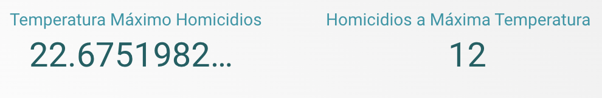

```python
Image(filename="/gdrive/My Drive/SMBD/img/MaxTemp_Hom.png")
```

```python
### 2. A qué temperatura ocurren más hurtos en la ciudad de Medellín?###
vista_minable[vista_minable['Tipo'] == 'Hurto'].groupby(['ValorObservado']).count().sort_values(by = 'Tipo', ascending = False)['Tipo']
```

```
ValorObservado
22.675198    812
22.871956    783
21.873658    328
21.773913    260
22.734406    226
            ...
18.848837      5
19.311364      5
19.400000      5
18.693478      5
18.716667      3
Name: Tipo, Length: 1248, dtype: int64
```

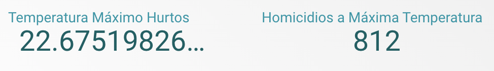

```python
Image(filename="/gdrive/My Drive/SMBD/img/MaxTemp_Hurtos.png")
```

```python
### 3. Por mes y sexo, cuál es la edad promedio de personas que son asesinadas en Medellín? ###
vista_minable[vista_minable['Tipo'] == 'Homicidio'].groupby(['añoMes','sexo'], as_index=False)['edad'].mean().sort_values(by = 'añoMes', ascending = True)
```

|  | añoMes | sexo | edad |
| --- | --- | --- | --- |
| 0 | 201801 | Hombre | 31.423077 |
| 1 | 201801 | Mujer | 26.250000 |
| 2 | 201802 | Hombre | 32.666667 |
| 3 | 201802 | Mujer | 49.000000 |
| 4 | 201803 | Hombre | 32.921053 |
| 5 | 201803 | Mujer | 31.000000 |
| 6 | 201804 | Hombre | 30.169811 |
| 7 | 201804 | Mujer | 30.000000 |
| 9 | 201805 | Mujer | 30.250000 |
| 8 | 201805 | Hombre | 30.383333 |
| 10 | 201806 | Hombre | 29.200000 |
| 11 | 201806 | Mujer | 18.000000 |
| 12 | 201807 | Hombre | 28.754717 |
| 13 | 201807 | Mujer | 24.000000 |
| 14 | 201808 | Hombre | 31.681818 |
| 15 | 201808 | Mujer | 40.333333 |
| 16 | 201809 | Hombre | 30.564103 |
| 17 | 201809 | Mujer | 28.000000 |
| 18 | 201810 | Hombre | 32.565217 |
| 19 | 201810 | Mujer | 40.666667 |
| 21 | 201811 | Mujer | 31.666667 |
| 20 | 201811 | Hombre | 28.523810 |
| 22 | 201812 | Hombre | 31.385965 |
| 23 | 201812 | Mujer | 2.000000 |
| 24 | 201901 | Hombre | 31.307692 |
| 25 | 201901 | Mujer | 28.666667 |
| 26 | 201902 | Hombre | 33.540000 |
| 27 | 201903 | Hombre | 27.580000 |
| 28 | 201903 | Mujer | 34.000000 |
| 30 | 201904 | Mujer | 38.375000 |
| 29 | 201904 | Hombre | 30.359375 |
| 32 | 201905 | Mujer | 28.666667 |
| 31 | 201905 | Hombre | 28.159420 |
| 33 | 201906 | Hombre | 37.076923 |
| 34 | 201906 | Mujer | 62.500000 |
| 35 | 201907 | Hombre | 31.435897 |
| 36 | 201907 | Mujer | 41.666667 |
| 37 | 201908 | Hombre | 29.386364 |
| 38 | 201908 | Mujer | 28.400000 |
| 39 | 201909 | Hombre | 35.612903 |
| 40 | 201909 | Mujer | 37.000000 |
| 41 | 201910 | Hombre | 28.451613 |
| 42 | 201910 | Mujer | 21.500000 |

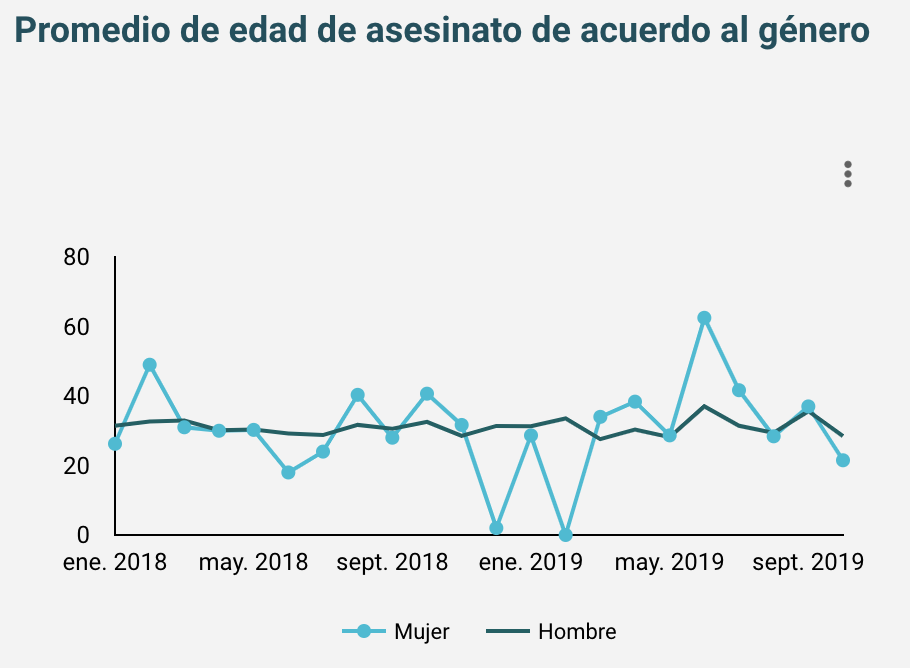

```python
Image(filename="/gdrive/My Drive/SMBD/img/edad_prom.png")
```

```python
### 4. Cuál es la modalidad de homicidios más común? ###
vista_minable[vista_minable['Tipo'] == 'Homicidio'].groupby(['modalidad']).count().sort_values(by = 'Tipo', ascending = False)['Tipo']
```

```
modalidad
Arma de fuego                      789
Cortopunzante                      244
Contundente                         40
Ahorcamiento o estrangulamiento     36
Asfixia mecánica                    14
Por establecer                       4
Explosivo                            3
Sumersión                            1
Name: Tipo, dtype: int64
```

La modalidad de homicidio más común en los años 2018 - 2019 es por arma de fuego en primer lugar, siguiendole cortopunzante.

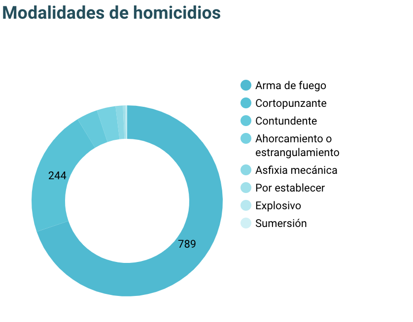

```python
Image(filename="/gdrive/My Drive/SMBD/img/modalida_homicidio.png")
```

```python
### 5. Cuáles son los 5 barrios con mayor incidencia en los homicidios de Medellín en los meses del 2018-2019? ###
vista_minable[vista_minable['Tipo'] == 'Homicidio'].groupby(['nombre_barrio']).count().sort_values(by = 'Tipo', ascending = False)['Tipo'].head(5)
```

```
nombre_barrio
La Candelaria              44
La Colina                  27
La Pradera                 26
Estación Villa             26
San José del Manzanillo    25
Name: Tipo, dtype: int64
```

Los barrios con mayor incidencia en los homicidios de Medellín en el 2018-2019 son: La calendaria, La colina, La pradera, Estación villa y San José de manzanillo.

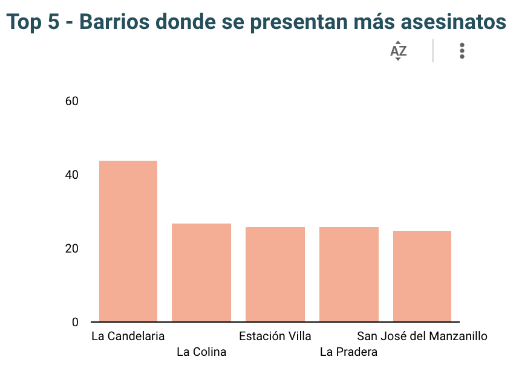

```python
Image(filename="/gdrive/My Drive/SMBD/img/Barrios_homicidio.png")
```

```python
### 6. Cuales son las 5 categorías de ítems que más se roban en Medellín? ###
vista_minable[vista_minable['Tipo'] == 'Hurto'].groupby(['categoria_bien']).count().sort_values(by = 'Tipo', ascending = False)['Tipo'].head(5)
```

```
categoria_bien
Tecnología                        28135
Documentos                        10377
Prendas de vestir y accesorios     8204
Dinero                             4980
Alimento                           2065
Name: Tipo, dtype: int64
```

Las categorías de ítems que más se roban en las residencias de Medellín en los años 2018 y 2019 son tecnología, documentos, prendas de vestir y accesorios, dinero y alimentos

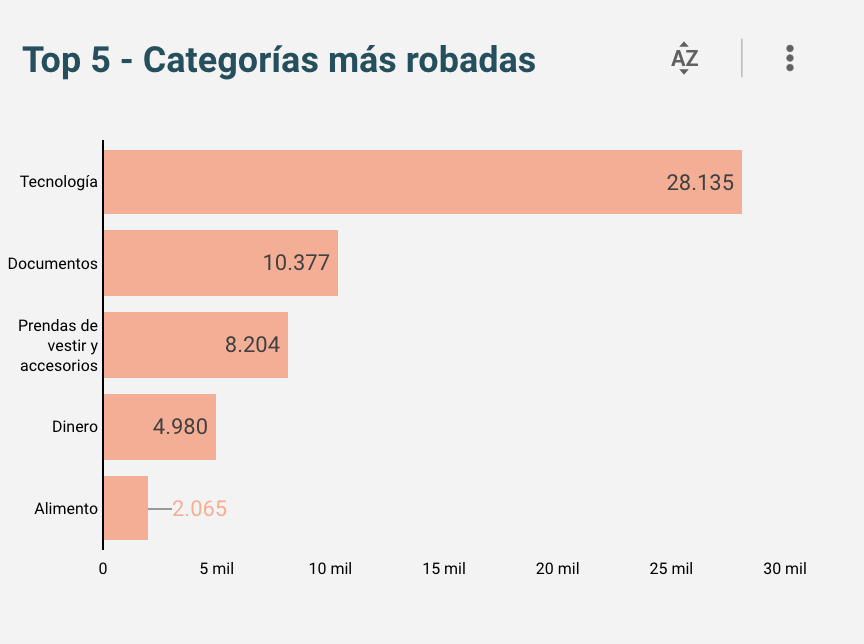

```python
Image(filename="/gdrive/My Drive/SMBD/img/cat_robo.png")
```

```python
### 7. Cual es la temperatura promedio anual por cada una de las modalidad de delincuencia? ###
vista_minable['año'] = vista_minable['fecha_hecho'].apply(lambda x: x.strftime('%Y'))
vista_minable.groupby(['Tipo'])['ValorObservado'].mean()
```

```
Tipo
Homicidio    21.388885
Hurto        22.147954
Name: ValorObservado, dtype: float64
```

La temperatura promedio para homicidios fue de 21.38 grados centigrados, para hurtos fue de 22.14

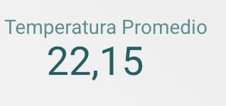

```python
Image(filename="/gdrive/My Drive/SMBD/img/temp_hurto.png")
```

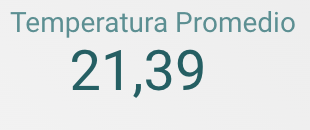

```python
Image(filename="/gdrive/My Drive/SMBD/img/temp_hom.png")
```

```python
### 8. Cuales son los 20 barrios donde más ocurren robos a lo largo de los meses del 2018-2019? ###
vista_minable[vista_minable['Tipo'] == 'Hurto'].groupby(['nombre_barrio']).count().sort_values(by = 'Tipo', ascending = False)['Tipo'].head(20)
```

```
nombre_barrio
La Candelaria             6378
Barrio Colón              1634
Guayaquil                 1472
El Poblado                1329
San Benito                1076
Villa Nueva               1024
Laureles                   994
Prado                      990
Bolivariana                933
Boston                     923
Perpetuo Socorro           860
San Diego                  806
Belén                      779
Barrio Colombia            766
Los Conquistadores         754
Patio Bonito               734
Naranjal                   725
Manila                     628
U.D. Atanasio Girardot     625
Sevilla                    615
Name: Tipo, dtype: int64
```

Los barrios donde más se presentaron hurtos en los años 2018 - 2019 fueron La Candelaria, Barrio Colón, Guayaquil, El Poblado, San Benito, Villa Nueva, Laureles, Prado, Bolivariana, Boston, Perpetuo Socorro, San Diego, Belén, Barrio Colombia, Los Conquistadores, Patio Bonito, Naranjal, Manila, U.D. Atanasio Girardot, Sevilla

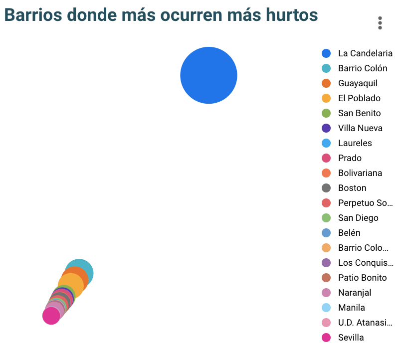

```python
Image(filename="/gdrive/My Drive/SMBD/img/barrio_hurto.png")
```

```python
### 9. Cuántos hombres y mujeres fueron asesinados en Medellín? ###
vista_minable[vista_minable['Tipo'] == 'Homicidio'].groupby(['sexo']).count()['Tipo']
# .groupby(['añoMes'], as_index=False)['edad'].mean().sort_values(by = 'añoMes', ascending = True)
```

```
sexo
Hombre    1057
Mujer       74
Name: Tipo, dtype: int64
```

Durante el 2018 y 2019 fueron asesinados 1057 hombres y 74 mujeres en la ciudad de Medellín

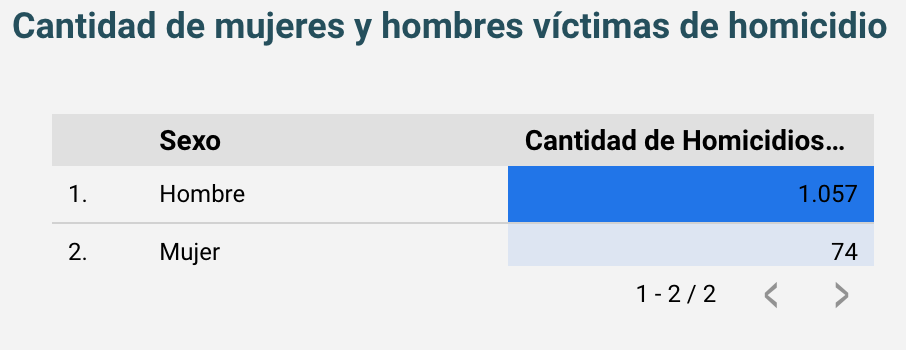

```python
Image(filename="/gdrive/My Drive/SMBD/img/Sexo_homicidio.png")
```

```python
### 10. A que se dedica la mayoría de personas asesinadas en Medellín? ###
vista_minable[vista_minable['Tipo'] == 'Homicidio'].groupby(['ocupacion']).count().sort_values(by='Tipo', ascending = False)['Tipo'].head(3)
```

```
ocupacion
Desempleado       223
Oficios varios    129
Comerciante       104
Name: Tipo, dtype: int64
```

De 1131 personas que fueron asesinadas entre 2018 y 2019, mayormente las víctimas son desempleados, comerciantes o se dedican a oficios varios

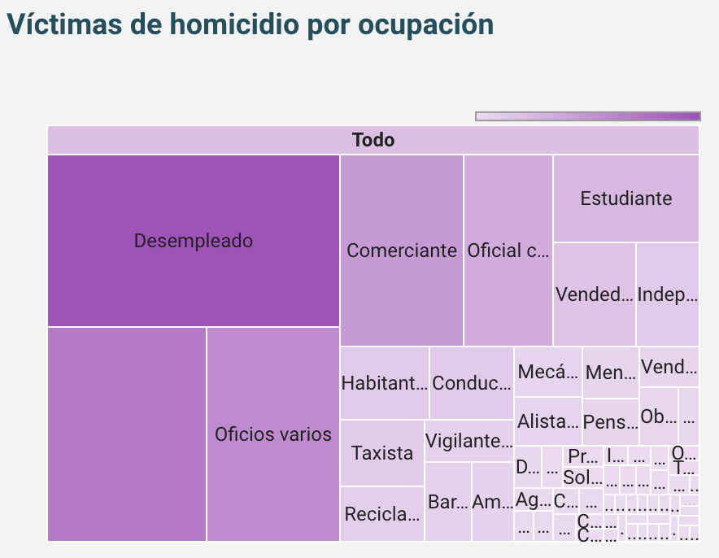

```python
Image(filename="/gdrive/My Drive/SMBD/img/Ocupacion_homicidio.png")
```

```python
### 11. Cuál es la edad promedio de personas asesinadas por barrio?
vista_minable[vista_minable['Tipo'] == 'Homicidio'].groupby(['nombre_barrio'])['edad'].mean().sort_values(ascending = False)
```

```
nombre_barrio
Juan Pablo II                 71.0
Piedras Blancas - Matasano    60.0
Estadio                       60.0
Santo Domingo Savio No.2      59.0
Andalucía                     59.0
                              ...
San Miguel                    16.0
Bermejal-Los Álamos           16.0
San Germán                    14.0
Las Granjas                   12.0
La Rosa                        4.0
Name: edad, Length: 236, dtype: float64
```

El barrio dónde asesinan en promedio las personas mas adultas es Juan Pablo II. Por otro lado, el barrio dónde asesinan en promedio menores es en La Rosa

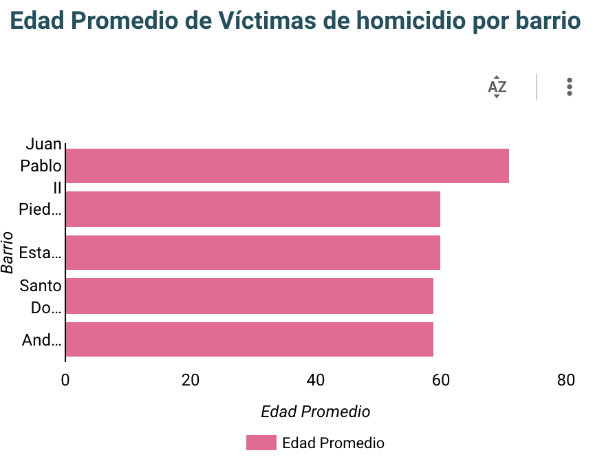

```python
Image(filename="/gdrive/My Drive/SMBD/img/edad_barrio_homicidio.png")
```

```python
### 12. Cual es la cantidad de personas asesinadas por lugar?
vista_minable[vista_minable['Tipo'] == 'Homicidio'].groupby(['lugar']).count().sort_values(by='Tipo', ascending = False)['Tipo']
```

```
lugar
Vía pública                   733
Residencia                     89
Zona boscosa                   51
Casa o apartamento             32
Vehículo particular            31
Quebrada o rio                 27
Bar o cantina                  17
Parque                         17
Taxi                           15
Local comercial                14
Bus de servicio público        12
Restaurante                     8
Escenario deportivo             8
Zona despoblada                 7
Parqueadero                     7
Almacén tienda y otro           6
Hospital o centro de salud      6
Taller mecánico                 5
Estación de Policía             4
Puente                          3
Billar                          3
Panadería                       3
Lote baldío                     2
Inquilinato                     2
Terminal de transporte          1
Batallón militar                1
Casino                          1
Banco                           1
Conjunto residencial            1
Río Medellín                    1
Estación del Metro              1
Puente peatonal                 1
Droguería o farmacia            1
Name: Tipo, dtype: int64
```

Generalmente los homicios durante 2018 y 2019 fueron cometidos en Vía pública

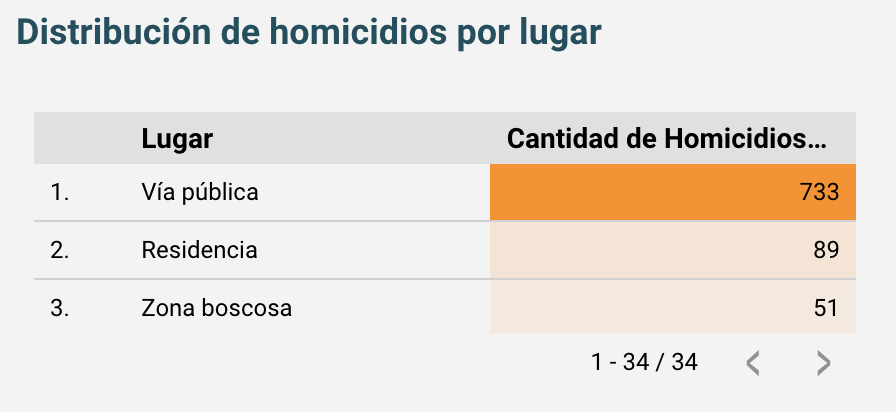

```python
Image(filename="/gdrive/My Drive/SMBD/img/Lugar_homicidio.png")
```

```python
### 13. Cuántos hurtos se dieron en Medellín y por qué modalidad?
print("En Medellín durante 2018 y 2019 se dieron", vista_minable[vista_minable['Tipo'] == 'Hurto']['Tipo'].count(), "casos de hurtos")
print(vista_minable[vista_minable['Tipo'] == 'Hurto'].groupby(['modalidad']).count().sort_values(by='Tipo', ascending = False)['Tipo'])
```

```
En Medellín durante 2018 y 2019 se dieron 60876 casos de hurtos
modalidad
Atraco                        30380
Descuido                      10660
Cosquilleo                     9110
Raponazo                       3596
Rompimiento cerraduta          2024
Sin dato                       1263
Rompimiento de ventana          933
Engaño                          888
Escopolamina                    786
Halado                          570
Comisión de delito              328
Llave maestra                   131
Ventosa                          79
Suplantación                     78
Paquete chileno                  23
Simulando necesidad              17
Rompimiento de caja fuerte        7
Retención de dinero               2
Clonación de tarjeta              1
Name: Tipo, dtype: int64
```

Las modalidad más cómun de hurto en Medellín durante 2018 y 2018 es Atraco, seguido por Descuido y Cosquilleo

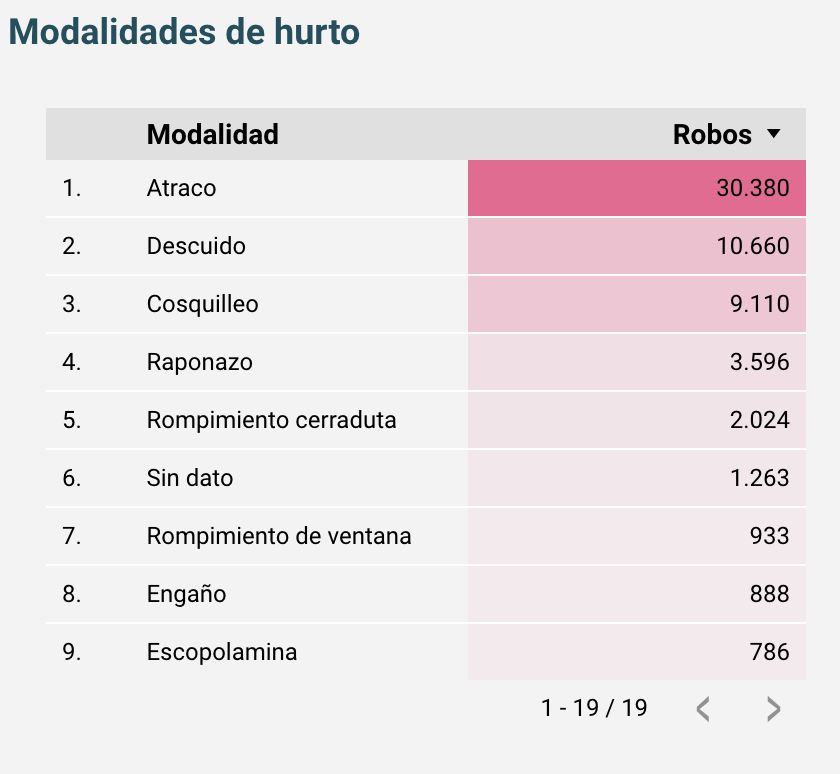

```python
Image(filename="/gdrive/My Drive/SMBD/img/modalidad_hurto.png")
```

```python
### 14. Cuantos hurtos ocurrieron por tipo de arma?
vista_minable[vista_minable['Tipo'] == 'Hurto'].groupby(['arma_medio']).count().sort_values(by='Tipo', ascending = False)['Tipo']
```

```
arma_medio
No                    29046
Arma de fuego         15315
Arma cortopunzante    11317
Objeto contundente     3525
Escopolamina           1092
Palanca                 427
Llave maestra           124
Sin dato                 29
Tóxico o Químico          1
Name: Tipo, dtype: int64
```

Durante 2018 y 2019, generalmente los hurtos se dieron sin usar armas, y en un segundo escalon se dieron con arama de fuego y arma cortopunzante.

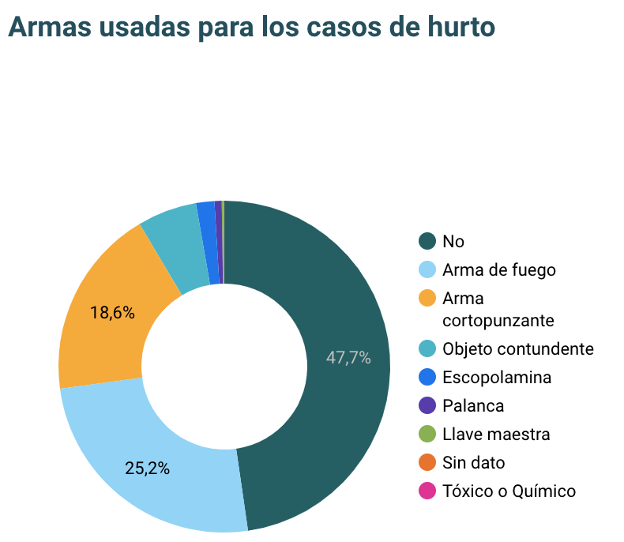

```python
Image(filename="/gdrive/My Drive/SMBD/img/arma_hurto.png")
```

```python
### 15. Cuáles fueron los bienes más hurtados en Medellín por grupo?
vista_minable[vista_minable['Tipo'] == 'Hurto'].groupby(['grupo_bien']).count().sort_values(by='Tipo', ascending = False)['Tipo']
```

```
grupo_bien
Mercancía                                          53373
 joyas                                              4980
Vehículo                                            1227
Tecnología                                           525
Sin dato                                             191
Prendas de vestir y accesorios                       124
Bélico                                               104
Documentos                                            63
Equipamiento                                          45
 Papelería y útiles                                   44
Otros elementos                                       36
 policía o vigilancia privada                         28
Vehículos de 2 o 4 ruedas                             23
Electrodomésticos                                     20
Celular                                               13
Autoparte y elementos de la mecánica automotriz       12
Maquinaria y equipo                                    8
Accesorios del hogar                                   7
Computador                                             6
Accesorios militares                                   5
Alimento                                               5
Herramientas                                           5
Arma de fuego                                          4
Licencia                                               4
Música                                                 3
Fauna                                                  3
Librería                                               2
Cédula                                                 2
Ropa exterior                                          2
Artículos médicos                                      2
Libreta militar                                        1
Billetera                                              1
Medicamento                                            1
Muebles                                                1
Elementos para actividades al aire libre               1
Elementos escolares                                    1
Software                                               1
Tarjeta para computador                                1
Accesorios celular                                     1
Accesorios prendas de vestir                           1
Name: Tipo, dtype: int64
```

Los grupo de bienes que mas fueron hurtados en 2018 y 2019 son Mercancía, joyas y vehículos

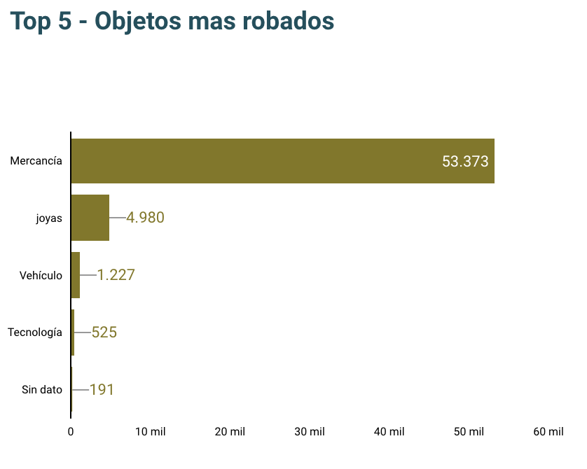

```python
Image(filename="/gdrive/My Drive/SMBD/img/obj_rob.png")
```

# **4.Diagramas de Base de Datos**

**Esquema Estrella**

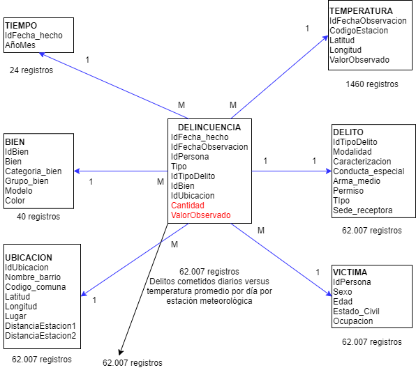

```python
Image(filename="/gdrive/My Drive/SMBD/img/DiagramaEstrella.png")
```

**Cubo**

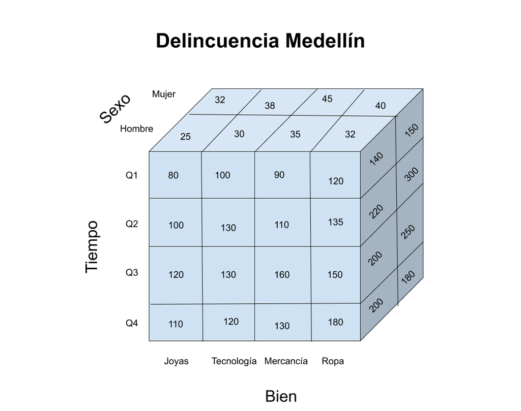

```python
Image(filename="/gdrive/My Drive/SMBD/img/Cubo.PNG")
```

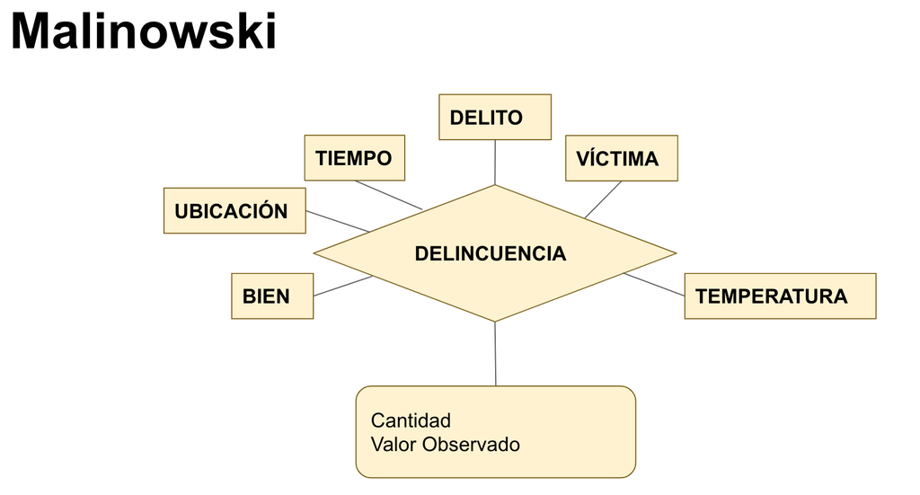

```python
Image(filename="/gdrive/My Drive/SMBD/img/malinowski.png")
```

# **5. Aplique MapReduce**

Apartir de la vista minable se llevo a la base de datos No Relacional MongoDB para responder la siguiente pregunta:

Cuál es la cantidad de Hombres y Mujeres que fueron victimas de delitos en Medellín en los años 2018-2019?

**Import**

mongoimport -d delincuencia -c homicidios_hurtos --type CSV --file vista_minable_temp_delitos.csv --headerline

**Map**

var map = function(){ emit(this["sexo"], 1)}

**Reducer**

var reduce = function(key, values){return Array.sum(values)}

**Ejecutar**

db.homicidios_hurtos.mapReduce(map, reduce, {out: {inline:true}})

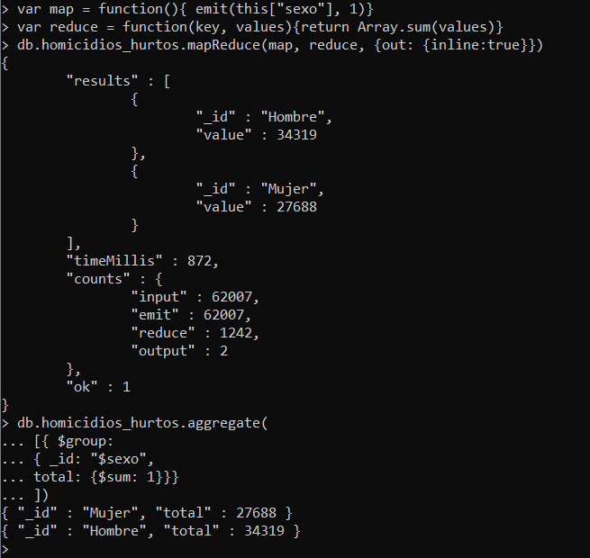

```python
Image(filename="/gdrive/My Drive/SMBD/img/MongoMapReduce.png")
```

# **6. Hipótesis**

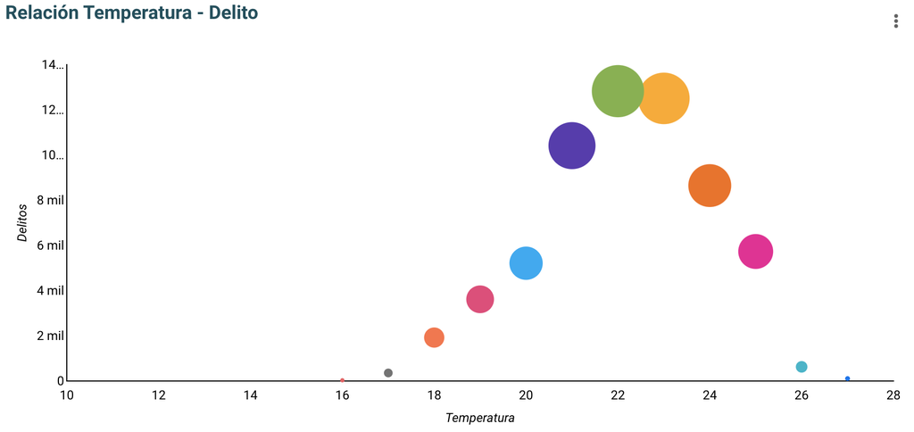

```python
Image(filename="/gdrive/My Drive/SMBD/img/hipotesis.png")
```

De acuerdo con el gráfico y con los datos, la hipótesis es falsa, ya que en temperaturas medias/altas es donde se presentan más delitos en la ciudad de Medellín

# **7. Predicción**

```python
vista_minable.head(2)
```

|  | fecha_hecho | sexo | edad | estado_civil | ocupacion | modalidad | caracterizacion | nombre_barrio | codigo_comuna | latitud | longitud | conducta_especial | arma_medio | lugar | sede_receptora | bien | categoria_bien | grupo_bien | modelo | color | permiso | Tipo | Distancia_Est1 | Distancia_Est2 | Estacion | ValorObservado | añoMes | año |
| --- | --- | --- | --- | --- | --- | --- | --- | --- | --- | --- | --- | --- | --- | --- | --- | --- | --- | --- | --- | --- | --- | --- | --- | --- | --- | --- | --- | --- |
| 0 | 2019-01-01 | Mujer | 24 | Soltero(a) | Sin dato | Raponazo | Sin dato | Plaza de Ferias | 5 | 6.301506 | -75.56368 | No | No | Vía pública | Castilla | Licencia | Documentos | Mercancía | -1 | Sin dato | Sin dato | Hurto | 5.701256 | 9.384524 | 27015290 | 21.5 | 201901 | 2019 |
| 1 | 2019-01-01 | Hombre | 26 | Soltero(a) | Sin dato | Descuido | Sin dato | Terminal de Transporte | 5 | 6.278288 | -75.57016 | Sin dato | No | Estación del Metro | Castilla | Sin dato tecnología | Tecnología | Mercancía | -1 | Sin dato | Sin dato | Hurto | 4.811562 | 6.705921 | 27015290 | 21.5 | 201901 | 2019 |

Valor promedio de la temperatura por mes

```python
vista_modelo = temperatura_dep.groupby(['FechaObservacion'])['ValorObservado'].mean().reset_index()
```

```python
vista_modelo['FechaObservacion'] = pd.to_datetime(vista_modelo['FechaObservacion'])
```

```python
vista_modelo.set_index('FechaObservacion', inplace=True)
print(vista_modelo.index)
```

```
DatetimeIndex(['2018-01-01', '2018-01-02', '2018-01-03', '2018-01-04',
               '2018-01-05', '2018-01-06', '2018-01-07', '2018-01-08',
               '2018-01-09', '2018-01-10',
               ...
               '2019-12-22', '2019-12-23', '2019-12-24', '2019-12-25',
               '2019-12-26', '2019-12-27', '2019-12-28', '2019-12-29',
               '2019-12-30', '2019-12-31'],
              dtype='datetime64[ns]', name='FechaObservacion', length=727, freq=None)
```

```python
y_vista = vista_modelo['ValorObservado'].resample('MS').mean().reset_index()
y_vista.head(3)
```

|  | FechaObservacion | ValorObservado |
| --- | --- | --- |
| 0 | 2018-01-01 | 20.355784 |
| 1 | 2018-02-01 | 21.516592 |
| 2 | 2018-03-01 | 21.470498 |

Análisis de temperatura

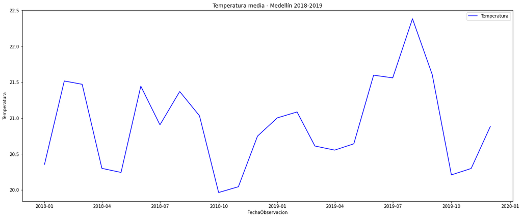

```python
plt.figure(figsize=(20, 8))
plt.plot(y_vista['FechaObservacion'], y_vista['ValorObservado'], 'b-', label = 'Temperatura')
plt.xlabel('FechaObservacion'); plt.ylabel('Temperatura'); plt.title('Temperatura media - Medellín 2018-2019')
plt.legend()
```

Entrenamiento y predicción usando prophet

```python
y_vista = y_vista.rename(columns={'FechaObservacion': 'ds', 'ValorObservado': 'y'})
modelo = Prophet(interval_width=0.95)
modelo.fit(y_vista)
```

```
INFO:fbprophet:Disabling yearly seasonality. Run prophet with yearly_seasonality=True to override this.
INFO:fbprophet:Disabling weekly seasonality. Run prophet with weekly_seasonality=True to override this.
INFO:fbprophet:Disabling daily seasonality. Run prophet with daily_seasonality=True to override this.
INFO:fbprophet:n_changepoints greater than number of observations. Using 18.
```

```
<fbprophet.forecaster.Prophet at 0x7fc1e7bd17b8>
```

```python
modelo_forecast = modelo.make_future_dataframe(periods=24, freq='MS')
modelo_forecast = modelo.predict(modelo_forecast)
```

Predicción de valores futuros

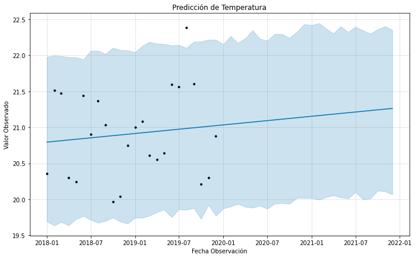

```python
plt.figure(figsize=(18, 6))
modelo.plot(modelo_forecast, xlabel = 'Fecha Observación', ylabel = 'Valor Observado')
plt.title('Predicción de Temperatura');
```

Exportación de archivo con datos predichos

```python
modelo_forecast.to_csv(
    '/gdrive/My Drive/SMBD/prediccion.csv',
    sep = ',',
    header = True,
    index = False)
```

```python
!jupyter nbconvert --to html /gdrive/My Drive/SMBD/SMBD_Delicuencia_vs_Temperatura.ipynb
```